# Bioinformatics for eDNA metabarcoding

Dr. Hugh Cross  
Dr. Lara Urban  
Dr. Gert-Jan Jeunen

## *Chapter 1: Quality control*

#### Introduction

As a start, let's navigate to our user `folder`. Next, we will copy the data over from the `resources folder` to our own `user folder`.

```
cd obsss_2020/users/gert-jan/

cp -r /nesi/project/nesi02659/obss_2020/resources/day5/eDNA /nesi/project/nesi02659/obss_2020/users/gert-jan

cd eDNA/

ls -ltr
```

Before we get started with the bioinformatics, we will familiarize ourselves with the folder setup. within the eDNA folder, we have seven subfolders:

1. notebooks: contain the supplementary information for this workshop
2. meta: contains the metadata used during the workshop
3. out: will contain any output fiels we generate during the workshop
4. raw: contains the raw sequencing file provided by the sequencing service
5. scripts: the folder we will use to create and run our bioinformatic scripts
6. stats: will be used for the statistical part of this workshop
7. taxonomy: will be used for the taxonomic assignment part of this workshop

#### Checking raw sequencing data files with text editors and FastQC

The first thing we need to do is check if the sequence file provided to us is in the correct format (software: text editor in terminal) and determine if there were no issues with our library during sequencing (software: FastQC). The sequencing service has provided us with an output file from the Illumina MiSeq sequencer. This file is in a `.fastq` format and zipped in our case to reduce the file size `.fastq.gz`. As a first step, we will unzip the file, as it might interfere with some of the downstream analysis we plan to do:

```
cd ../raw/

gunzip FTP103_S1_L001_R1_001.fastq.gz
```

As you learned during Day 1 of the workshop, the `.fastq` format is a text-based format for storing both a biological sequence and the corresponding quality scores. The layout is predetermined, with four lines per sequence:

1. line 1: begins with a `@` character and is followed by a sequence identifier
2. line 2: is the raw sequence letters
3. line 3: is the line separating the sequence and quality scores with a `+`
4. line 4: encodes the quality values for the sequence in line 2

Now that we have unzipped our sequencing file, we can see that we have the normal `.fastq` in our raw folder.

```
ls -ltr
```

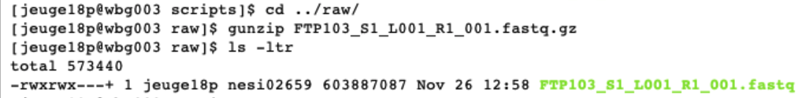

Due to the size of the file, opening them in text editors can be problematic. Luckily, we can check the layout of the file using the text editor in the terminal. So, let's look at the first 12 lines of the raw sequencing file.

```
head -12 FTP103_S1_L001_R1_001.fastq
```

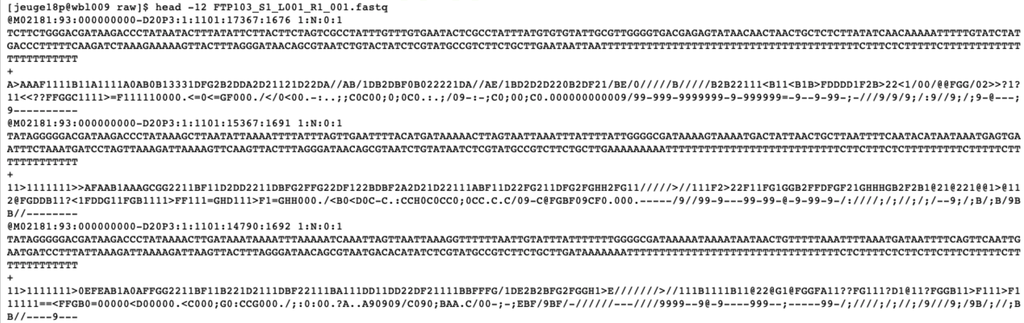

From the output, we can see the first twelve lines of our raw sequencing file (the lines containing the actual sequence and quality scores are wrapped over multiple lines) following the structure we described above.

Next, we will look at the quality of the raw sequencing file to make sure no issues arose during sequencing. The program we will be using is FastQC (website: [**https://www.bioinformatics.babraham.ac.uk/projects/fastqc/**](https://www.bioinformatics.babraham.ac.uk/projects/fastqc/)). This software has a graphical user interface (GUI). However, today we will be using the command line option. This program will report on basic statistics, quality of the data, sequencing length, etc. Before we can run the software, we need to load in the module to make it accessible to us.

```
module load FastQC/0.11.9

fastqc FTP103_S1_L001_R1_001.fastq
```

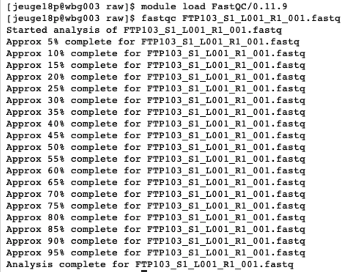

When running this command, an `.html` file will be created in our raw folder. When opening this (double clicking), it will direct us to an interactive document. For eDNA data, we want to check in this report that:

1. The *per base sequence quality* stays within the green area.
2. The *number of sequences* you received.
3. The data does not contain *N* bases.
4. All sequences have *the same length*, equal to the cycle number of the sequencing kit.

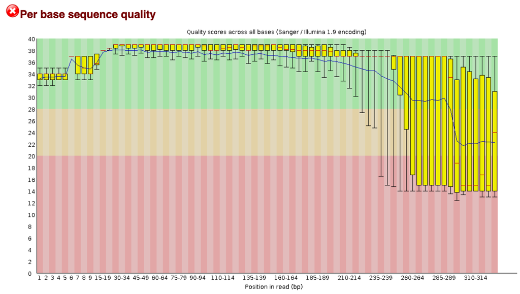

## *Chapter 2: Demultiplexing sequencing data*

#### Introduction

Now that we have checked the raw sequencing file and made sure everything is ready to process our data, we will assign each sequence to the corresponding sample, a process referred to as demultiplexing.

As mentioned during the introduction presentation, each sample was assigned a specific barcode combination, with at least three base pair differences between each barcode used in the library. By searching for these specific sequences, which are situated at the very beginning and very end of each sequence, we can assign each sequence to its sample. We will be using OBITools (website: [**https://pythonhosted.org/OBITools/welcome.html**](https://pythonhosted.org/OBITools/welcome.html)) for demultiplexing our dataset today, as it is one of the few software programs that can simultaneously detect dual barcodes. OBITools requires an additional text file with information about the barcode sequences assigned to each sample and primer sequences used to amplify the DNA. The text file is formatted in a way, so that you have a single line per sample with information separated by tabs. The forward and reverse barcode (indicated in the text file by ‘tags’) are separated by ‘:’. This file has been provided to you in the folder ‘meta’. Let's open this file to see how it is structured.

```
cd ../meta/

nano Aramoana_prelim_barcode_info.txt
```

[figure not shown]

While assigning each sequence to a sample, OBITools will remove the barcode and primer sequences of each sequence. Therefore, no additional step is needed when using this software. This, however, is not always the case when using different software programs.

#### Assigning sequences to corresponding samples

**(! This step will be omitted for the workshop due to time constraints !)**

```
ngsfilter -t ../meta/Aramoana_prelim_barcode_info.txt -u ../out/unidentified.fasta -e 1 FTP103_S1_L001_R1_001.fastq > ../out/assigned.fastq

obistat -c sample ../out/assigned.fastq

obiannotate -k sample ../out/assigned.fastq ../out/annotated.fastq

obisplit -t sample ../out/annotated.fastq

cd ../scripts/

nano relabel
#!/bin/bash

cd ../out/

for fq in FTP103_A*; do usearch -fastx_relabel $fq -prefix $fq. -fastqout relabeled_$fq; done

cat relabeled_* > relabeled.fastq
```

We can check this `relabeled.fastq` file in our `out` folder and see that the names of the sequences have changed to our sample names.

```
head -12 ../out/relabeled.fastq
```

## *Chapter 3: Quality filtering*

#### Introduction

During the quality filtering step, we will discard all sequences that do not adhere to a specific set of rules. We will be using the program USEARCH for this step (website: [**https://www.drive5.com/usearch/**](https://www.drive5.com/usearch/)). During the quality filtering, we will discard all sequences that have one or multiple unassigned bases, denoted as ‘N’ in the sequence. Sequences shorter than our amplicon length will be discarded as well. Lastly, we will filter out sequences that have an expected error higher than 1.0. This expected error is representative of a miscalled base in our sequence by the Illumina MiSeq sequencing machine.

#### Filtering data based on quality and length

Now that we'll be using a different software program, we'll need to load the module of USEARCH

```
module load USEARCH/11.0.667-i86linux32
```

The file we will be working on is `relabeled.fastq` and is placed in the `out` folder. We will now be making our first bioinformatcs script in the `scripts` folder and execute the command from there.

```
cd ../scripts/

nano quality.sh

#!/bin/bash

cd ../out/

usearch -fastq_filter relabeled.fastq -fastq_maxee 1.0 -fastq_minlen 150 -fastq_maxns 0 -fastqout filtered.fastq -fastaout filtered.fasta
```

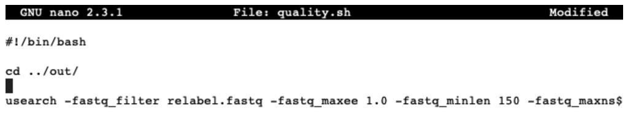

Once the script is written we will exit and save by pressing `ctr + X`. Next, we need to make the file executable and run the script by:

```
chmod +x quality.sh

./quality.sh
```

The command `nano quality.sh` will generate a new file with the name `quality.sh` and open it for us in the command line text editor. The first line of the script will start with ‘#!/bin/bash’, telling the computer what kind of code is written inside the script and how it needs to be interpreted. In the next line, we will specify the directory where our file is located. `usearch` is the software we will use to filter our data based on quality and what follows are different parameters to filter our data and produce output files.

When executing this script, USEARCH will provide us with information about how many sequences or ‘reads’ were found in the ‘relabeled.fastq’ file and how many sequences passed our filtering parameters. These sequences are written to two files, one `.fastq` file and one `.fasta` file. The only difference between the two files is that the `.fastq` file will contain information on the quality of the sequences.

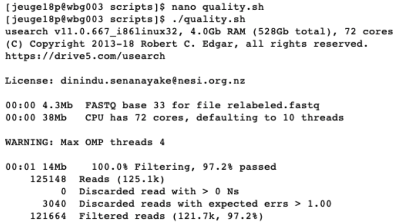

To check if these files have been generated, we can list all the files in the `out` directory and read the files to determine their structure. It is always a good strategy to check intermediate steps to make sure the code is doing what it is supposed to do. Besides just checking if the files are there, we can even count the number of sequences in each file to see if it matches what USEARCH reported on.

```
ls -ltr ../out/

less ../out/filtered.fastq

q

less ../out/filtered.fasta

q

grep -c "^@" ../out/filtered.fastq

grep -c "^>" ../out/filtered.fasta
```

The command `less` will open a text editor to view the `filtered.fastq` and `filtered.fasta` files. Pressing enter will move us down line by line and exiting the text editor can be done by pressing `q`. When looking at the structure of both files, we can see that each sequence in the fastq file starts with `@` and in the fasta file with `>`. Knowing this, we can use the `grep` command to count the number of instances these two characters occur at the beginning of the line in our files, thereby counting the number of sequences in our files. The output shows us the identical number of sequences as reported by USEARCH.

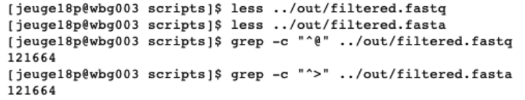

The `filtered.fastq` file has been generated for the sole purpose to determine if the quality filtering was successful. We, therefore, will run the `fastqc` command on the `filtered.fastq` file and compare the two `fastqc` reports. An example figure of the report can be found below. Do you see the differences compared with the raw data file?

```
fastqc ../out/filtered.fastq
```

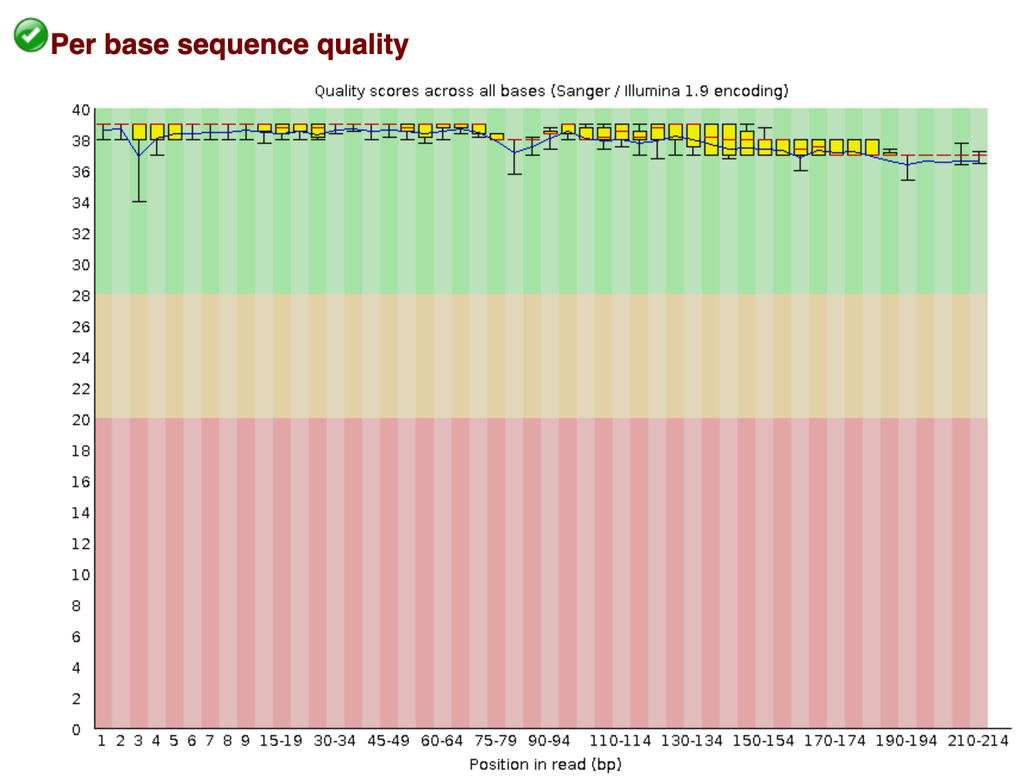

From this report, we can see that:

1. The number of sequences has reduced, due to discarding poor quality sequences.
2. The per base quality has improved.
3. The length of the sequences has changed and is now reflecting the amplicon size.

## *Chapter 4: Denoising or clustering*

#### Introduction

Now that we have a high quality data file `filtered.fasta` that contains information about which sequence belongs to what sample, we are ready for the next step in our bioinformatics’ pipeline, i.e., looking for biologically meaningful OR biologically correct sequences. This is done through denoising or clustering the dataset, while at the same time removing any chimeras and left-over PCR and/or sequencing errors.

Scientists are currently debating on what the best approach is to obtain `biologically meaningful` or `biologically correct` sequences. There are numerous papers published on this topic. Unfortunately, this is something that is outside the scope of this workshop to go into at depth. But here is the basic information…

There are basically two trains of thought, clustering the dataset or denoising the dataset. With clustering the dataset, an OTU sequence should be at least a given percentage different from all other OTUs and should be the most abundant sequence compared to similar sequences. People traditionally chose to cluster at 97%, which means that the variation between sequences should be at least 3%. The concept of OTU clustering was introduced in the 1960s and has been debated ever since. With denoising the dataset, on the other hand, the algorithm attempts to identify all correct biological sequences in the dataset, which is visualized in the figure below. This schematic shows a clustering threshold at 100% and trying to identify errors based on abundance differences. The retained sequences are called ZOTU or Zero-radius Operational Taxonomic Unit. In other software programs they might also be called ASVs.

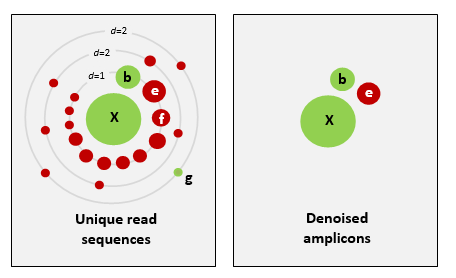

This difference in approach may seem small but has a very big impact on your final dataset!

When you denoise the dataset, it is expected that one species may have more than one ZOTU, while if you cluster the dataset, it is expected that an OTU may have more than one species assigned to it. This means that you may lose some correct biological sequences that are present in your data when you cluster the dataset, because they will be clustered together. In other words, you will miss out on differentiating closely related species and intraspecific variation. For denoising, on the other hand, it means that when the reference database is incomplete, or you plan to work with ZOTUs instead of taxonomic assignments, your diversity estimates will be highly inflated.

For this workshop, we will follow the denoising pathway, since most people are working on vertebrate datasets with good reference databases and are interested in taxonomic assignments.

#### Finding unique sequences and sorting by abundance

Prior to clustering or denoising, we need to dereplicate our data into unique sequences. Since metabarcoding data is based on an amplification method, the same starting DNA molecule can be sequenced multiple times. In order to reduce file size and computational time, it is convenient to combine these duplicated sequences as one and retain information on how many were combined. Additionally, we will remove sequences that only occur once in our data and attribute them to sequence and PCR error. Lastly, we will sort the sequences based on abundance.

```
nano uniques.sh

#!/bin/bash

cd ../out/

usearch -fastx_uniques filtered.fasta -fastaout uniques.fasta -relabel Uniq. -sizeout -minuniquesize 2

usearch -sortbysize uniques.fasta -fastaout sorted.fasta
```

Once the script is written we will exit and save by pressing ‘ctr + X’. Next, we need to make the file executable and run the script by:

```
chmod +x uniques.sh

./uniques.sh
```

When executing this script, USEARCH will let us know how many unique sequences were found and how many of those only occurred once. In the next part, USEARCH also let us know how many unique sequences were sorted based on abundance.

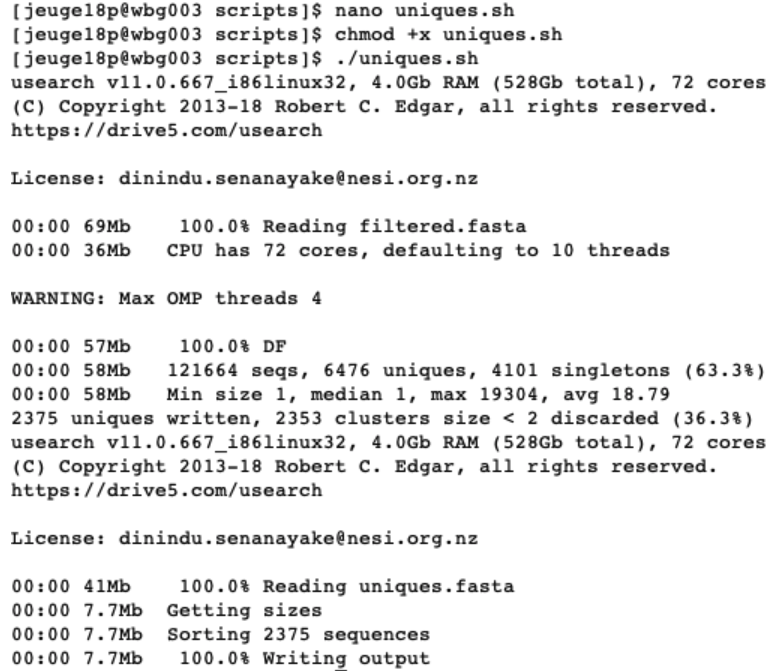

If the script successfully executed, we will now have generated two new files `uniques.fasta` (containing information on the number of unique sequences and their abundance from the filtered `filtered.fasta` file) and `sorted.fasta` (identical to `uniques.fasta`, but sorted by abundance). Let’s open them and see what is inside.

```
ls -ltr ../out/

less ../out/sorted.fasta

q

grep -c "^>" ../out/sorted.fasta
```

We now see that the names of our sequences have changed, due to the ‘-relabel’ parameter. We also have some additional information following the name, where size is indicating the number of times this unique sequence was found across the full dataset.

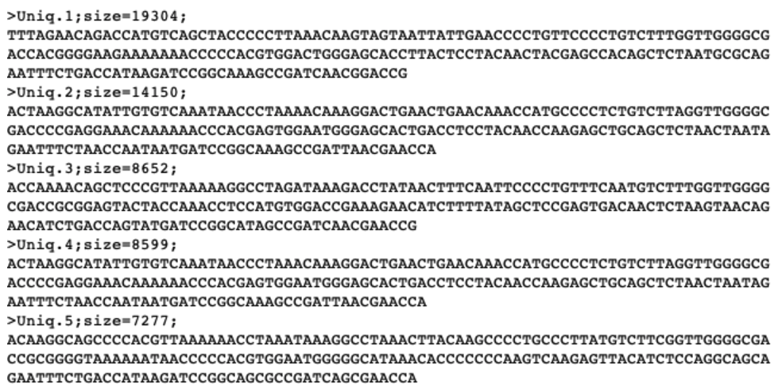

#### Denoising the dataset

Now we can use the `sorted.fasta` file to obtain `biologically meaningful` sequences by denoising the data with the following script.

```
nano denoise.sh

#!/bin/bash

cd ../out/

usearch -unoise3 sorted.fasta -zotus zotus.fasta -tabbedout unoise3.txt
```

Once the script is written we will exit and save by pressing `ctr + X`. Next, we need to make the file executable and run the script by:

```
chmod +x denoise.sh

./denoise.sh
```

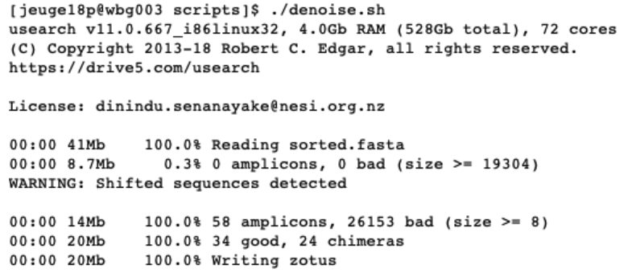

After denoising, we are left with 58 amplicon sequences, of which 34 are considered as good and 24 as chimeras. This script will have generated the `zotus.fasta` file, which we will use in the next chapter for taxonomic assignment.

#### Generating a ZOTU table

All that is left to do is generating a ZOTU table. Such a table will have the same format as a count table from traditional survey techniques, where we have the species names as rows, sample locations as columns, and counts in each cell. For metabarcoding data, we will have ZOTU names as rows, sample locations as columns, and number of sequences in each cell.

```
nano zotutable.sh

#!/bin/bash

cd ../out/

usearch -otutab relabeled.fastq -zotus zotus.fasta -otutabout zotutab.txt
```

Once the script is written we will exit and save by pressing `ctr + X`. Next, we need to make the file executable and run the script by:

```
chmod +x zotutable.sh

./zotutable.sh
```

To generate the ZOTU table, we used the prefiltered `relabeled.fastq` file. The reasoning behind this is that if the sequence matches the ZOTU generated on high quality data, we would like to include it, even though it has been assigned as a low-quality sequence.

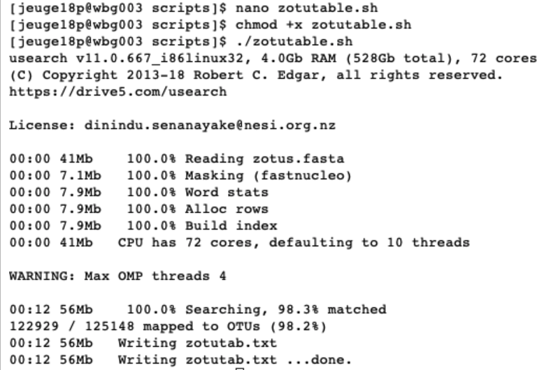

The ZOTU table is a general text file and can be opened for easy viewing.

Before we move to the next part of the workshop, taxonomic assignment, you might have wondered why we are making all these scripts? We could of course just enter the commands in the scripts in the command line and they would work just as well. The point of this is that there is a lot of trial and error happening when figuring out the correct parameters. You, therefore, would work on a small subset of data that would include a positive control from a mock community, your negative control and a couple of samples. We write these scripts to test the output on this small dataset. Once we get everything working, we can write one general script that invokes all the other ones and will run on the full dataset.

Let's show this in an example:

```
cd ../out/

shopt -s extglob

rm -- !(relabeled.fastq)

cd ../scripts/

nano run.sh

#!/bin/bash

./quality.sh
./uniques.sh
./denoise.sh
./zotutable.sh

chmod +x run.sh
./run.sh
```

We'll now move on to the next part of the workshop, taxonomic assignment.

**Thank you very much for your attention!**